# DC Maps

This is just a general use DC map creating script. It has been initiated to provide Yesim with a couple maps, but it can become a gallery over time.

```python
#Enable R capability
%load_ext rmagic
```

```python
%%R
library(maptools)
library(gpclib)
library(sp)
library(ggmap)
library(rgdal)
library(raster)

#Read in Ward shapefile
w<-readShapeSpatial('/home/choct155/Google Drive/Dissertation/Data/spatial/DC/WardPly.shp')
projection(w) <- '+proj=lcc +lat_1=38.3 +lat_2=39.45 +lat_0=37.66666666666666 +lon_0=-77.0 +x_0=400000.0 +y_0=0.0 +datum=NAD83 +units=m +no_defs'
print(summary(w))
```

```
Checking rgeos availability: TRUE
General Polygon Clipper Library for R (version 1.5-5)
	Type 'class ? gpc.poly' for help
rgdal: version: 0.8-10, (SVN revision 478)
Geospatial Data Abstraction Library extensions to R successfully loaded
Loaded GDAL runtime: GDAL 1.9.0, released 2011/12/29
Path to GDAL shared files: /usr/share/gdal/1.9
Loaded PROJ.4 runtime: Rel. 4.7.1, 23 September 2009, [PJ_VERSION: 470]
Path to PROJ.4 shared files: (autodetected)
Object of class SpatialPolygonsDataFrame
Coordinates:
       min      max
x 389613.7 407881.7
y 124876.9 147558.5
Is projected: TRUE
proj4string :
[+proj=lcc +lat_1=38.3 +lat_2=39.45 +lat_0=37.66666666666666
+lon_0=-77.0 +x_0=400000.0 +y_0=0.0 +datum=NAD83 +units=m +no_defs
+ellps=GRS80 +towgs84=0,0,0]
Data attributes:
    OBJECTID         WARD           FID_        NAME              REP_NAME
 Min.   :1.00   Min.   :1.00   Min.   :0   Ward 1 :1   Jack Evans     :1
 1st Qu.:2.75   1st Qu.:2.75   1st Qu.:0   Ward 2 :1   Jim Graham     :1
 Median :4.50   Median :4.50   Median :0   Ward 3 :1   Kenyan McDuffie:1
 Mean   :4.50   Mean   :4.50   Mean   :0   Ward 4 :1   Marion Barry   :1
 3rd Qu.:6.25   3rd Qu.:6.25   3rd Qu.:0   Ward 5 :1   Mary M. Cheh   :1
 Max.   :8.00   Max.   :8.00   Max.   :0   Ward 6 :1   Muriel Bowser  :1
                                           (Other):2   (Other)        :2
        GIS_ID                                       WEB_URL
 Ward00_001:1   http://dccouncil.us/council/jack-evans   :1
 Ward00_002:1   http://dccouncil.us/council/jim-graham   :1
 Ward00_003:1   http://dccouncil.us/council/marion-barry :1
 Ward00_004:1   http://dccouncil.us/council/mary-m.-cheh :1
 Ward00_005:1   http://dccouncil.us/council/muriel-bowser:1
 Ward00_006:1   http://dccouncil.us/council/tommy-wells  :1
 (Other)   :2   (Other)                                  :2
          REP_PHONE                  REP_EMAIL
 (202) 724-8028:1   jackevans@dccouncil.us:1
 (202) 724-8045:1   jgraham@dccouncil.us  :1
 (202) 724-8052:1   kmcduffie@dccouncil.us:1
 (202) 724-8058:1   mbarry@dccouncil.us   :1
 (202) 724-8062:1   mbowser@dccouncil.us  :1
 (202) 724-8068:1   mcheh@dccouncil.us    :1
 (Other)       :2   (Other)               :2
                                      REP_OFFICE    WARD_ID      LABEL
 1350 Pennsylvania Ave, Suite 102, NW 20004:1    1      :1   Ward 1 :1
 1350 Pennsylvania Ave, Suite 105, NW 20004:1    2      :1   Ward 2 :1
 1350 Pennsylvania Ave, Suite 106, NW 20004:1    3      :1   Ward 3 :1
 1350 Pennsylvania Ave, Suite 107, NW 20004:1    4      :1   Ward 4 :1
 1350 Pennsylvania Ave, Suite 108, NW 20004:1    5      :1   Ward 5 :1
 1350 Pennsylvania Ave, Suite 110, NW 20004:1    6      :1   Ward 6 :1
 (Other)                                   :2    (Other):2   (Other):2
    AREASQMI        SHAPE_AREA   SHAPE_LEN
 Min.   : 2.536   Min.   :0    Min.   :0
 1st Qu.: 8.069   1st Qu.:0    1st Qu.:0
 Median : 8.906   Median :0    Median :0
 Mean   : 8.565   Mean   :0    Mean   :0
 3rd Qu.:10.526   3rd Qu.:0    3rd Qu.:0
 Max.   :11.938   Max.   :0    Max.   :0
```

**UPDATE**: Note that the following information ended up being crucial in defining the projection (failing to incorporate all of it caused problems later):

Lambert_Conformal_Conic:

```
Standard_Parallel: 38.300000
Standard_Parallel: 39.450000
Longitude_of_Central_Meridian: -77.000000
Latitude_of_Projection_Origin: 37.666667
False_Easting: 400000.000000
False_Northing: 0.000000
```

No, I had no idea what the proper projection/datum combination was at the outset. It turns out that the combination from the tutorial (longlat/WGS84), while popular, was not appropriate here. R complained about non-conformant data. Thus, it was a great opportunity to find the right information. Fortunately, DC GIS does a great job of providing a lot of information about the sets. Here is the [detailed record](http://dcatlas.dcgis.dc.gov/metadata/WardPly.html) for the WardPly.

Unfortunately, there is a lot of information, and I was unsure of what I was looking for. [PROJ4](https://trac.osgeo.org/proj/) cartographic library to rescue! I had previously installed this guy to get through the tutorial, and the relevant executable (*proj*) sits on my path. When I need a list of projections and/or datums to choose from (or help me figure out what information to pull from detailed metadata), I can call it directly. What? I need a projection??

```python
!proj -lp | grep Lambert
```

```
laea : Lambert Azimuthal Equal Area
lcc : Lambert Conformal Conic
lcca : Lambert Conformal Conic Alternative
leac : Lambert Equal Area Conic
```

How do I figure out what datum to use?

```python
!proj -ld
```

```
__datum_id__ __ellipse___ __definition/comments______________________________
       WGS84 WGS84        towgs84=0,0,0
      GGRS87 GRS80        towgs84=-199.87,74.79,246.62
                          Greek_Geodetic_Reference_System_1987
       NAD83 GRS80        towgs84=0,0,0
                          North_American_Datum_1983
       NAD27 clrk66       nadgrids=@conus,@alaska,@ntv2_0.gsb,@ntv1_can.dat
                          North_American_Datum_1927
     potsdam bessel       towgs84=606.0,23.0,413.0
                          Potsdam Rauenberg 1950 DHDN
    carthage clark80      towgs84=-263.0,6.0,431.0
                          Carthage 1934 Tunisia
hermannskogel bessel       towgs84=653.0,-212.0,449.0
                          Hermannskogel
       ire65 mod_airy     towgs84=482.530,-130.596,564.557,-1.042,-0.214,-0.631,8.15
                          Ireland 1965
      nzgd49 intl         towgs84=59.47,-5.04,187.44,0.47,-0.1,1.024,-4.5993
                          New Zealand Geodetic Datum 1949
      OSGB36 airy         towgs84=446.448,-125.157,542.060,0.1502,0.2470,0.8421,-20.4894
                          Airy 1830
```

Ballin! Ok, that was a somewhat unreasonable amount of excitement over executing bash calls from within the Notebook. Moving on to the taks at hand, we need to translate the shapefile into a data.frame so ggmap can make things happen.

```python
%%R
#Convert to r data.frame
ward<-fortify(w)
print(head(ward))
```

```
      long      lat order  hole piece group id
1 402567.4 132857.7     1 FALSE     1   0.1  0
2 402580.3 132832.7     2 FALSE     1   0.1  0
3 402581.7 132830.0     3 FALSE     1   0.1  0
4 402584.6 132824.4     4 FALSE     1   0.1  0
5 402587.5 132818.9     5 FALSE     1   0.1  0
6 402590.4 132813.4     6 FALSE     1   0.1  0
```

And, now we can actually map the Wards.

```
Google Maps API Terms of Service : http://developers.google.com/maps/terms
Google Maps API Terms of Service : http://developers.google.com/maps/terms
```

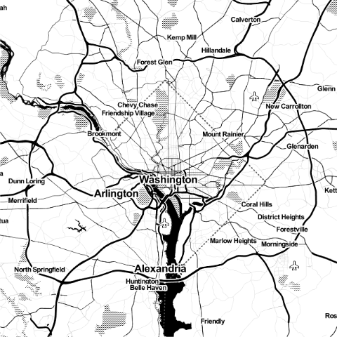

```python
%%R
#Create base map
dcmap<-qmap('washington dc',zoom=11,maptype='toner',source='stamen')

#Combine ward data with base map
print(dcmap + geom_polygon(aes(x=long,y=lat,group=group),
                           data=ward,colour='white',fill='red',alpha=.5,size=.2))
```

So, where the F is my map? I see my base map, and I know I have my WardPly in... Upon closer inspection, my coordinates are Eastings and Northings! How inconvenient, but an issue that is likely to come up with some frequency given the sheer volume of projections out there. We need to convert these data to *longlat* so that they mesh with my basemap. Hopefully this can be done with spTransform. I know that I was previously able to map with a *longlat* projection and the *WGS84* datum...

```python
%%R
#Check coordinates before transform
print(coordinates(w))

#Convert to longlat projection
ward_ll<-spTransform(w,CRS('+proj=longlat +datum=WGS84'))

#Check coordinates after transform
print(coordinates(ward_11))
```

```
      [,1]     [,2]
0 399427.5 130267.6
1 399759.7 135439.8
2 404525.2 135461.5
3 396243.8 136153.8
4 397275.4 139738.5
5 401260.0 139728.3
6 393151.8 140945.3
7 397041.1 143991.4
Error in print(coordinates(ward_11)) :
  error in evaluating the argument 'x' in selecting a method for function 'print': Error in coordinates(ward_11) :
  error in evaluating the argument 'obj' in selecting a method for function 'coordinates': Error: object 'ward_11' not found
```

```
Google Maps API Terms of Service : http://developers.google.com/maps/terms
Google Maps API Terms of Service : http://developers.google.com/maps/terms
```

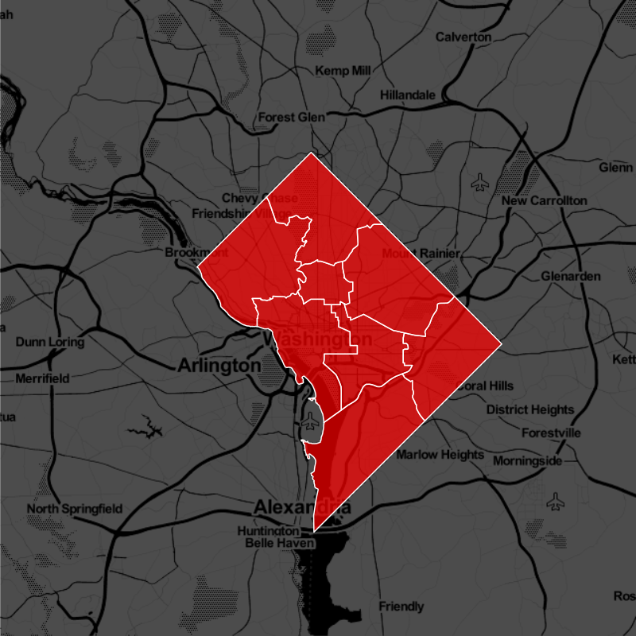

```python
%%R -w 800 -h 800

#Convert from SpatialPolygonsDataFrame to data.frame
ward<-fortify(ward_ll)

#Create base map
dcmap<-qmap('washington dc',zoom=11,maptype='toner',source='stamen',darken=.7)

#Combine ward data with base map
print(dcmap + geom_polygon(aes(x=long,y=lat,group=group),
                           data=ward,colour='white',fill='red',alpha=.7,size=.7))
#ggsave('dcmap.png')
```

```
Google Maps API Terms of Service : http://developers.google.com/maps/terms
Google Maps API Terms of Service : http://developers.google.com/maps/terms
```

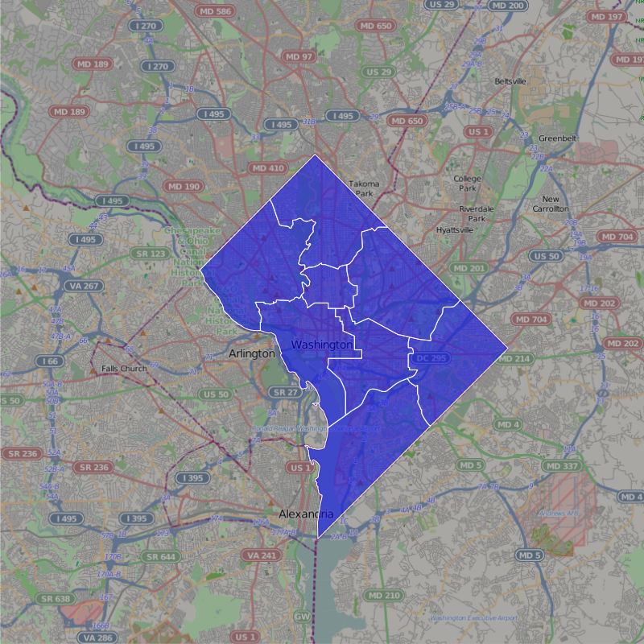

```python
%%R -w 800 -h 800

#Create base map
dcmap2<-qmap('washington dc',zoom=11,source='osm',darken=.3)

#Combine ward data with base map
print(dcmap2 + geom_polygon(aes(x=long,y=lat,group=group),
                           data=ward,colour='white',fill='blue',alpha=.5,size=.5))
```